# Point estimate

ryamada

2019/09/28

1. Use R. Make a function to calculate mean of values of a vector. Don’t use R’s mean() function! [help](https://swcarpentry.github.io/r-novice-inflammation/02-func-R/)
2. See the right-side panel of Wikipedia article of “Binomial distribution” and find the formula of mean of it. Pick value for two parameters, n and p, so that mean is the area of a circle of radius 10. Generate a vector of 100000 random values in the binomial distribution. Draw a histogram of r.
3. Calculate mean of r. You can use your mean function or mean() function in R. Check the mean is close to the area of the circle.
4. Let’s assume r is the series of experiments to know about the variable. You can assume the initial n elements of r is the result of n experiments. Using this idea, you can calculate the series of mean along with the increase of number of experiments from 1 to 100000. Make a vector of the means in two ways.
   - Use “for loop”.
   - Use [“cumsum()”](https://www.r-bloggers.com/two-new-cumulative-sum-functions-2/) and [“: (colon)”](https://stat.ethz.ch/R-manual/R-devel/library/base/html/Colon.html) . This way is much faster…
5. Draw the sequence of means with a horizontal line indicating the “true value”. The behavior indicates the point estimates converges to the true value. Type “line” would be better than the other types of [plot()](https://www.rdocumentation.org/packages/graphics/versions/3.6.1/topics/plot) function. You should draw two the converging line graphs; from 1 to 100000 and from 1 to somewhere that tells you more about the converging behavior.
6. When you want to know the converging behavior is typical or not, you should repeat the procedure many times. Try the following three ways.
   - Repeat the procedure 10 times and keep the results in 100000 x 10 matrix, X. Draw multiple converging lines with matplot() function. Now you should get familiar with [“help(matplot)”](https://www.r-project.org/help.html) command to get information of specified functions.
   - A quick-and-dirtier way is to reuse r with 100000 elements. Shuffle r with sample() function and used the new value vector as a new series of experiments. Although this gives you multiple series of expriments, they are not mutually independent, strictly. Becaues the number of elements are not small, this quick-and-dirty way will work for you to get an idea of similarity among repetition.
   - Actually you can avoid the loop of 10 times by generatin 100000 x 10 random values at once. Put the values in 100000 x 10 matrix. You can get the series of means for each columns. To get the series, you can use apply() function.

```r
my.mean <- function(x){
  sum(x)/length(x)
}
my.mean(1:10)
```

```
## [1] 5.5
```

```r
a <- pi * 10^2
p <- runif(1)
n <- ceiling(a/p)
p <- a/n
r <- rbinom(100000,n,p)
```

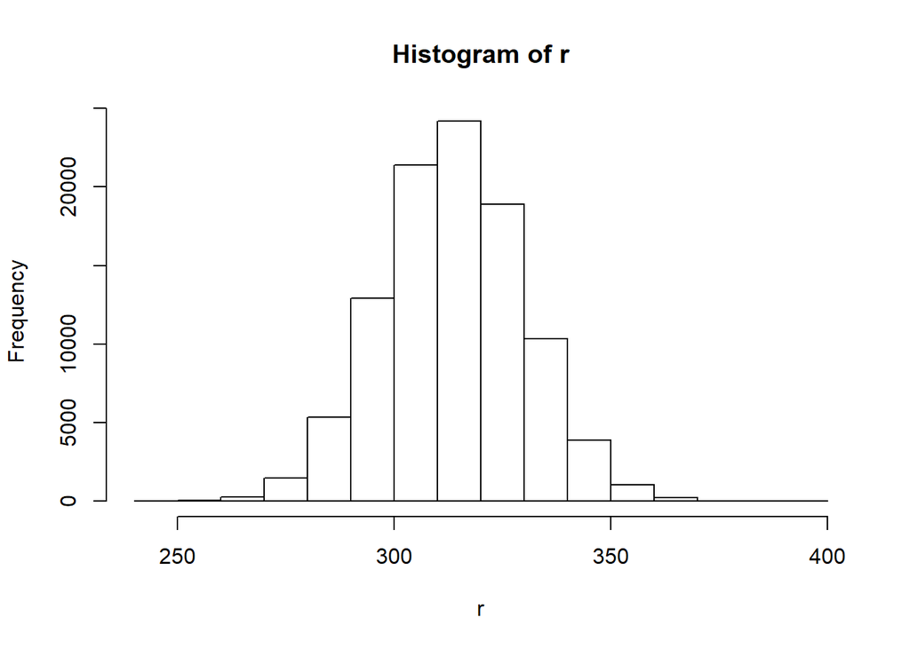

```r
hist(r)
```

```r
mean(r)
```

```
## [1] 314.1343
```

```r
pi * 10^2
```

```
## [1] 314.1593
```

```r
mean.seq1 <- rep(0,100000)
for(i in 1:100000){
  mean.seq1[i] <- mean(r[1:i])
}
mean.seq2 <- cumsum(r)/(1:100000)
```

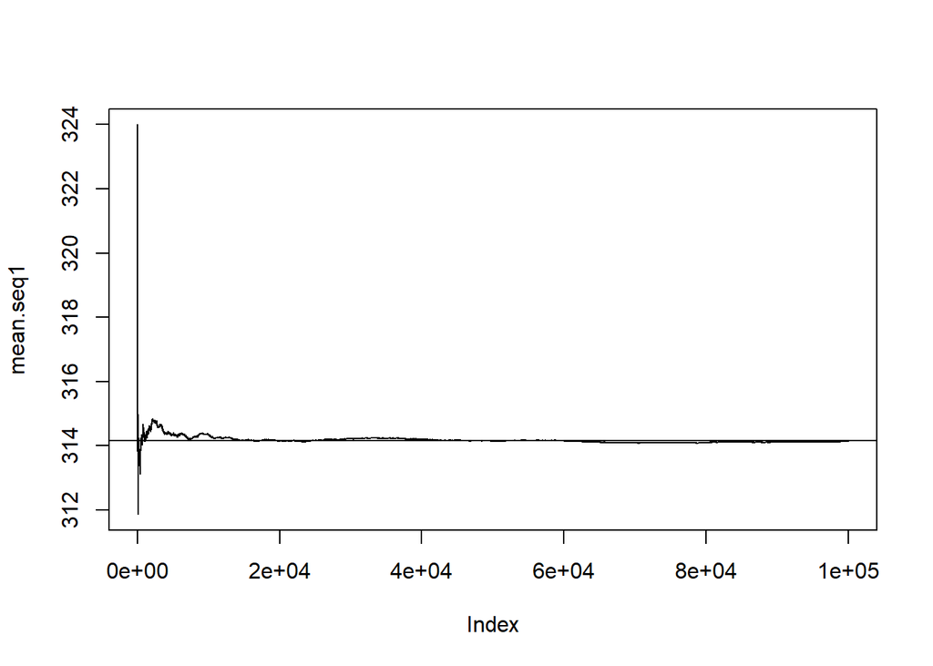

```r
plot(mean.seq1,type="l")
abline(h=pi*10^2)
```

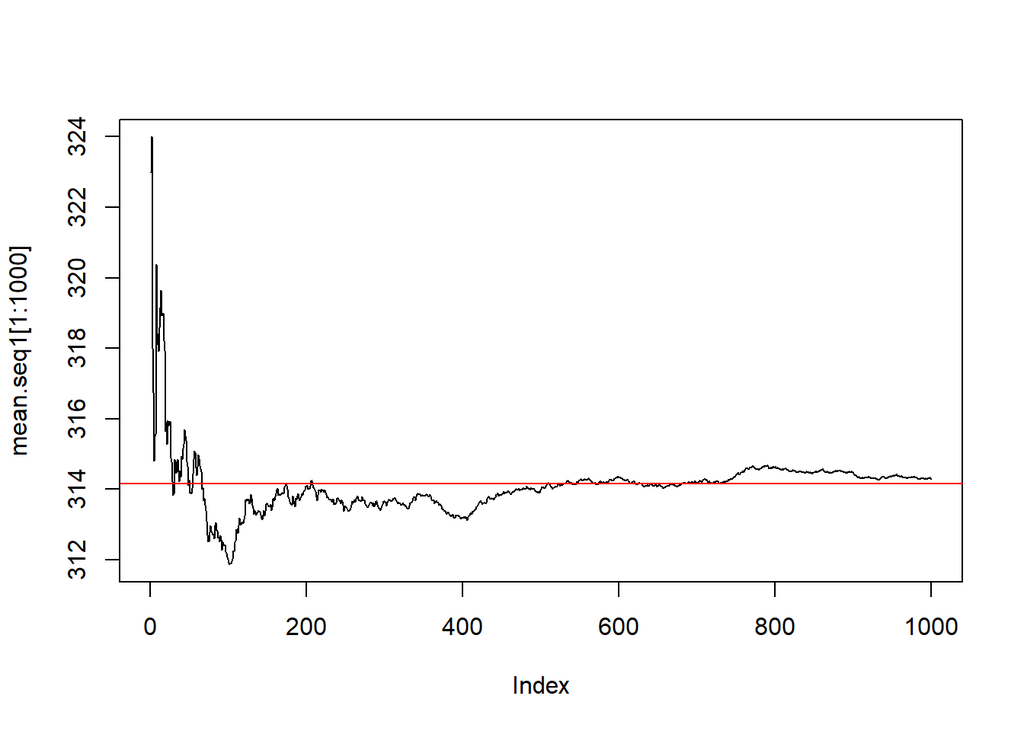

```r
plot(mean.seq1[1:1000],type="l")
abline(h=pi*10^2,col=2)
```

```r
X <- matrix(0,100000,10)
for(i in 1:10){
  r <- rbinom(100000,n,p)
  X[,i] <- cumsum(r)/(1:100000)
}
```

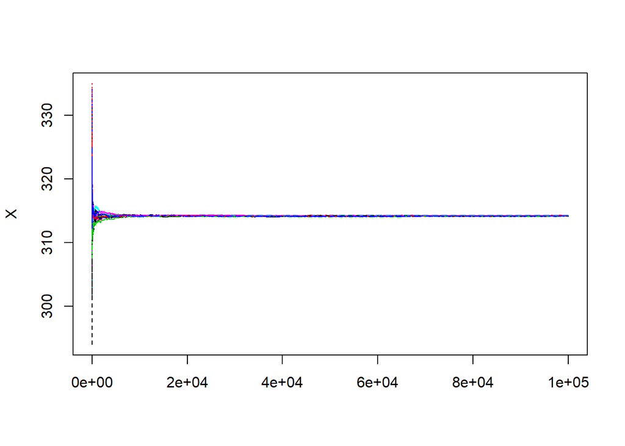

```r
matplot(X,type="l")
```

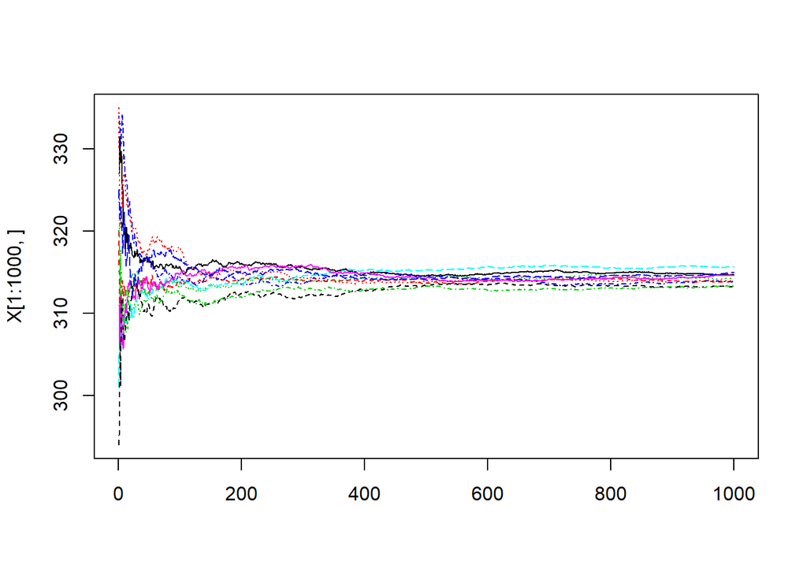

```r
matplot(X[1:1000,],type="l")
```

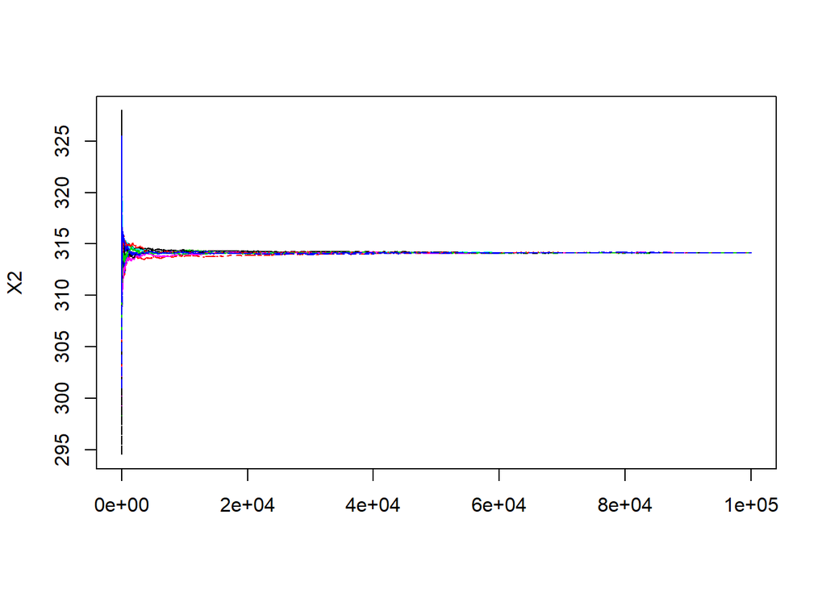

```r
X2 <- matrix(0,100000,10)
for(i in 1:10){
  X2[,i] <- cumsum(sample(r))/(1:100000)
}
matplot(X2,type="l")
```

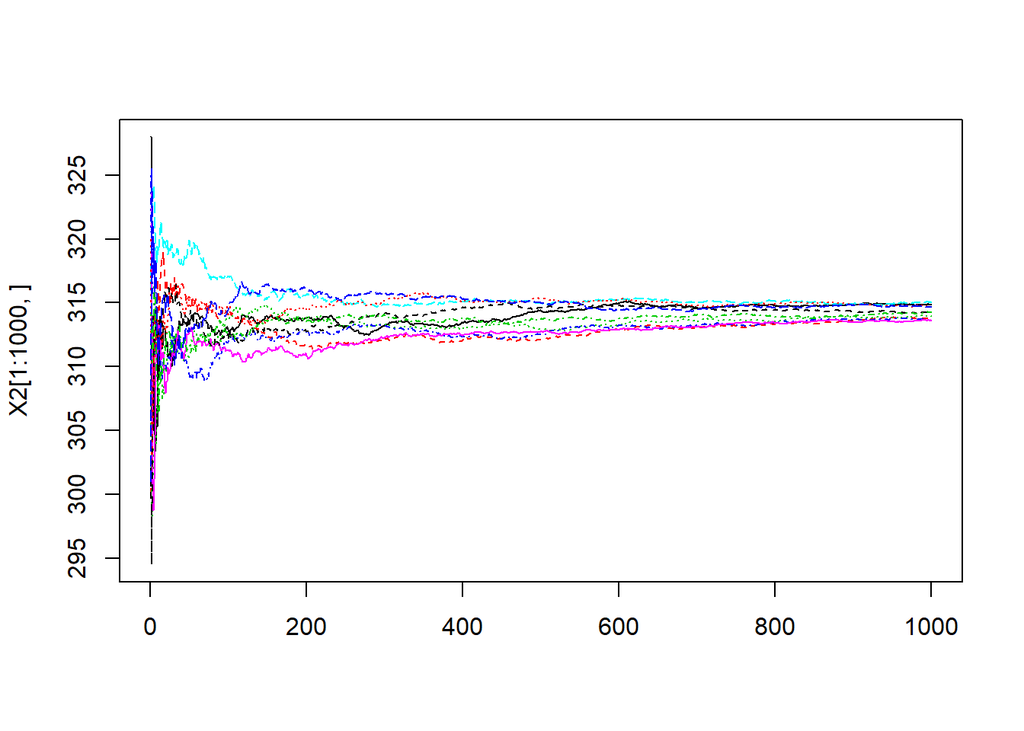

```r
matplot(X2[1:1000,],type="l")
```

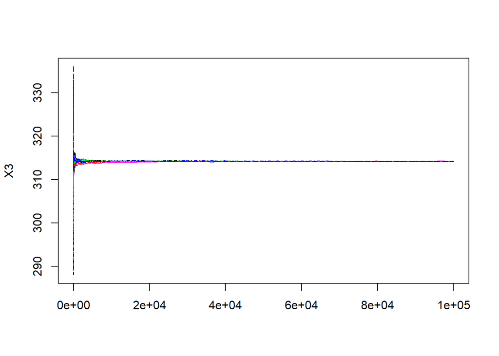

```r
R <- matrix(rbinom(100000 * 10,n,p),ncol=10)
tmp.fx <- function(x){
  cumsum(x)/(1:length(x))
}
X3 <- apply(R,2,tmp.fx)
matplot(X3,type="l")
```

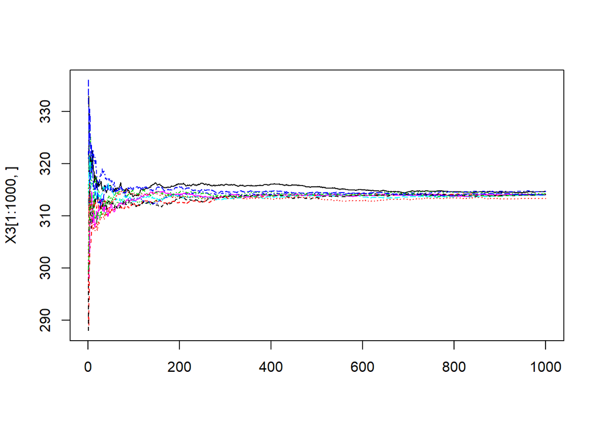

```r
matplot(X3[1:1000,],type="l")
```